# Clustering Clusters

6/28/2018

## Input data

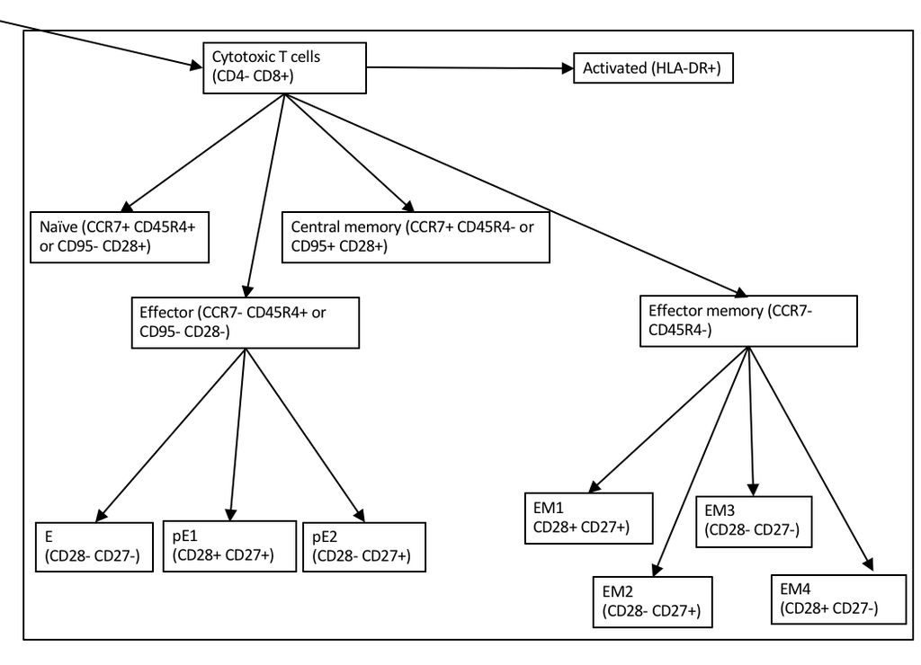

- running phenograph on Cytotoxic T cells from non-“manual” study samples
- used following markers CD27, CD28, CD95, CCR7, CD45RA, CD8, CD4, CD3, CD19, IgD, HLA.DR

## Phenograph Clusters detected

[interactive chart not shown]

- only within control sample “A”
- n = 35 fcs files

## Phenograph Clusters detected

[interactive chart not shown]

- only within control sample “A”
- spearman rho 0.3458118

## Characterizing Phenograph Clusters

- For each Phenograph Cluster:
  - compute percent of each known cell type is present
- group common centroids together

## Characterizing Phenograph Clusters

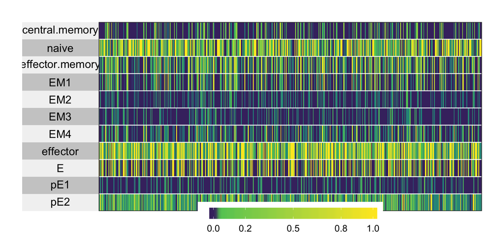

- “x”-axis bars are individual phenograph clusters
- “y”-axis is the percent of that population represented in the cluster

## Characterizing Phenograph Clusters

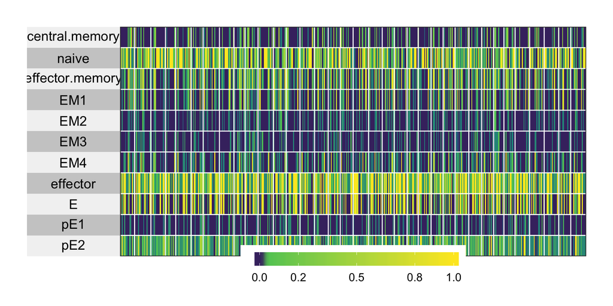

- “x”-axis white lines separating individual CtlA .fcs files
- “y”-axis is the percent of that population represented in the cluster

## Characterizing Phenograph Clusters

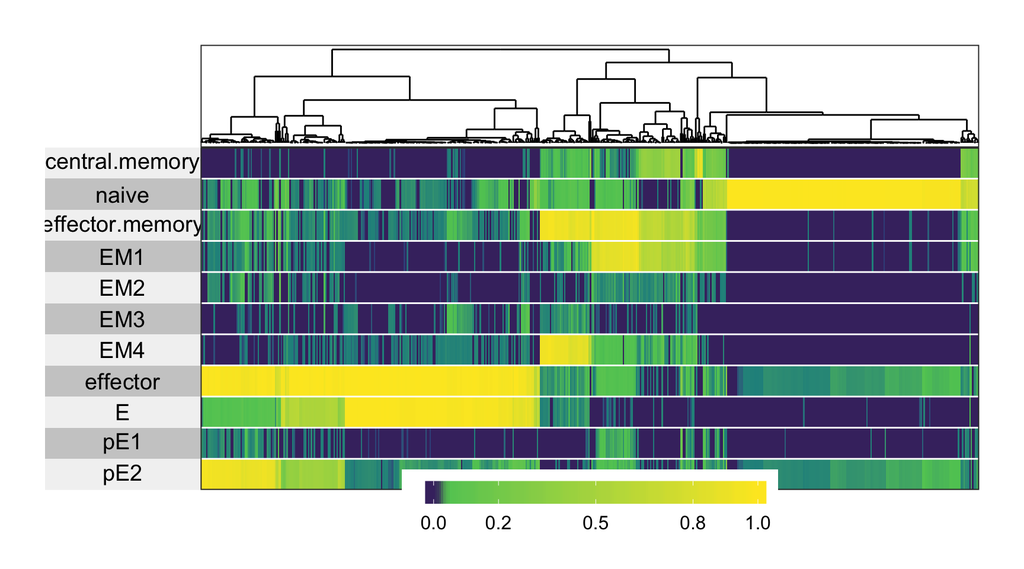

- “x”-axis ordered by common phenograph clusters
- sorta grouped by “meta” clusters

## Phenograph Clusters detected

[interactive chart not shown]

- all Ctl files
- n = 205 fcs files

## Events in Phenograph Clusters

[interactive chart not shown]

- all Ctl files

## Events in Phenograph Clusters

[interactive chart not shown]

- all Ctl files

## Events in Phenograph Clusters

[interactive chart not shown]

- all Ctl files

## Phenograph Clusters detected

[interactive chart not shown]

- all Ctl files
- spearman rho 0.4428928

## Characterizing Phenograph Clusters

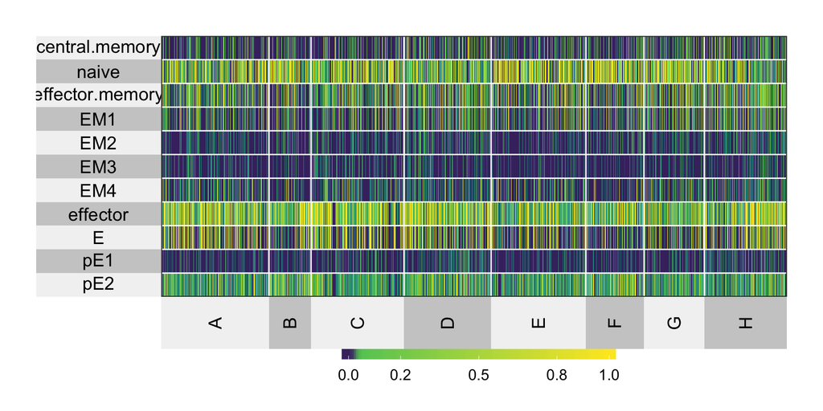

- “x”-axis white lines separating individual Ctls (multiple .fcs)
- color = frequency of cell type in cluster

## Characterizing Phenograph Clusters

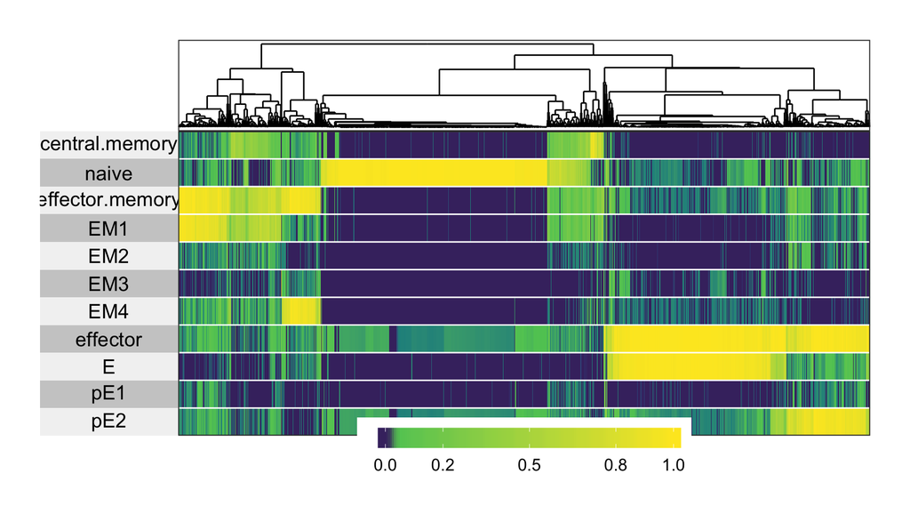

- “x”-axis ordered by common phenograph clusters